# **Clustering en K grupos**

Este algoritmo no jerárquico nos permite clasificar nuestro dataset en K grupos, lo más homogeneo posible a lo interno de los grupos y lo más disímiles entre grupos.

En este ejemplo crearemos un dataset dummy centrado en 4 puntos, con dos variables numéricas. La idea es clasificar los sujetos en cuatro (4) grupos.

```python
import os
os.chdir('C:\\Users\\GalindezR\\Desktop\\personal\\k_means')
```

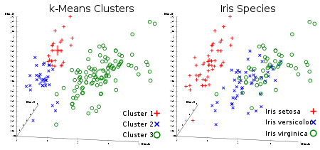

```python
from IPython.display import Image
Image(".//img//k_means.png")
```

Importamos las librerías y módulos a utilizar:

```python
import pandas as pd
import numpy as np
import matplotlib.pyplot as plt
import seaborn as sns
from sklearn.datasets import make_blobs
```

Creemos un dataser de ejemplo con dos (variables)

```python
datos = make_blobs(n_samples=200, n_features=2, centers = 4)
```

A continuación vemos los 200 registros creados, con sus dos variables, además del grupo al cual pertenece (del 0 al 3)

```python
datos[0]
```

```
array([[-3.73115793e+00, -1.05765541e+00],
       [-2.79014630e+00, -2.40897141e+00],
       [-3.60747496e+00, -2.54727797e+00],
       [-5.42514947e+00,  2.60454314e+00],
       [-4.42092424e+00, -4.19456509e+00],
       [-4.31223720e+00,  3.28289713e+00],
       [ 4.27847394e-01, -7.66042725e-02],
       [ 1.73880991e+00,  1.21410426e+00],
       [-4.27632714e+00,  2.83806625e+00],
       [-4.89529413e+00,  1.43467561e+00],
       [ 1.06950780e+01, -3.36947795e+00],
       [ 7.86366460e+00, -4.09495830e+00],
       [-1.68463674e+00, -3.93776259e+00],
       [ 1.33360143e+00,  2.27341347e+00],
       [-7.42828218e+00,  2.90065854e+00],
       [ 9.80768252e+00, -3.76614405e+00],
       [-6.28810720e+00,  2.78095135e+00],
       [ 9.90462710e+00, -8.93032613e-01],
       [ 2.30550841e+00,  3.65658627e+00],
       [-2.97331102e+00, -1.23652518e+00],
       [ 1.56891218e+00,  9.25437555e-01],
       [ 9.19375029e+00, -3.76537428e+00],
       [-3.83552684e+00, -2.41641457e+00],
       [ 2.49610432e+00,  1.09790173e+00],
       [ 2.41443357e-01,  1.84592722e+00],
       [-2.15551181e+00, -1.32678605e+00],
       [ 9.41857362e+00, -5.03604904e+00],
       [ 9.31580944e+00, -4.88843649e+00],
       [-5.03963599e+00,  3.26037310e+00],
       [ 1.16080189e+00,  4.18671597e+00],
       [-4.82052656e+00, -3.01109055e+00],
       [-3.97967857e+00, -2.64180586e+00],
       [ 8.98329311e+00, -2.54260700e+00],
       [-5.25585520e+00,  3.35330751e+00],
       [ 9.98403860e+00, -2.95021788e+00],
       [ 8.74413316e+00, -2.86058102e+00],
       [ 9.20307308e+00, -3.58530257e+00],
       [-5.34870606e+00, -2.40977955e+00],
       [ 9.93445880e+00, -3.08753249e+00],
       [ 9.33957236e+00, -3.14350010e+00],
```

[output cut: 145 more lines]

```
       [-6.15829261e+00,  4.74617473e+00],
       [ 1.05338694e+01, -4.57469195e+00],
       [-1.41535112e+00,  1.12113075e+00],
       [-2.25150891e+00, -1.65022836e+00],
       [ 1.32267436e+00,  3.52427777e+00],
       [ 1.05382531e+01, -4.23050028e+00],
       [ 8.54813247e-01,  2.38177116e+00],
       [-3.63014085e+00, -9.89736140e-01],
       [ 6.53557170e+00, -3.49904147e+00],
       [ 8.36038865e+00, -3.24001429e+00],
       [ 8.77992071e-01,  3.04544543e+00],
       [-5.23252171e+00,  3.56392060e+00],
       [-5.47470423e+00,  5.22252524e+00],
       [ 1.37446059e+00, -4.82488316e-01],
       [-2.28094214e+00, -5.72647890e-01]])
```

```python
datos[1]
```

```
array([2, 2, 2, 0, 2, 0, 3, 3, 0, 0, 1, 1, 2, 3, 0, 1, 0, 1, 3, 2, 3, 1,
       2, 3, 3, 2, 1, 1, 0, 3, 2, 2, 1, 0, 1, 1, 1, 2, 1, 1, 2, 2, 0, 1,
       3, 3, 2, 1, 3, 3, 2, 1, 3, 2, 3, 1, 0, 2, 1, 0, 0, 2, 1, 0, 2, 2,
       3, 1, 0, 3, 0, 3, 1, 0, 0, 0, 2, 0, 3, 0, 1, 3, 0, 0, 3, 0, 1, 2,
       2, 3, 3, 2, 1, 2, 3, 2, 2, 1, 1, 1, 1, 3, 1, 0, 3, 3, 3, 3, 2, 0,
       0, 0, 2, 3, 3, 1, 1, 3, 2, 0, 0, 0, 3, 1, 1, 3, 0, 2, 3, 1, 3, 2,
       0, 1, 2, 0, 3, 0, 0, 0, 1, 0, 3, 3, 0, 3, 2, 3, 1, 1, 3, 2, 2, 0,
       3, 1, 2, 0, 0, 0, 2, 2, 2, 2, 1, 2, 1, 2, 2, 1, 2, 2, 2, 0, 3, 1,
       0, 0, 3, 1, 0, 0, 1, 3, 1, 0, 1, 3, 2, 3, 1, 3, 2, 1, 1, 3, 0, 0,
       3, 2])
```

En el siguiente scatterplot podemos observar claramente como los datos, tal como lo definimos con la función **`make_blobs`**, se encuentran concentrados en cuatro (4) grupos (que en la vida real estos grupos son desconocidos y es lo que querríamos investigar: a qué grupo pertenece cada punto)

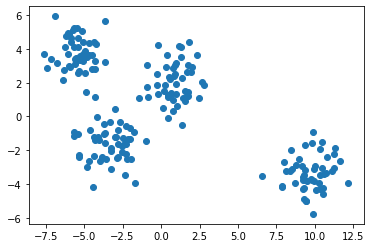

```python
plt.scatter(datos[0][:,0],datos[0][:,1])
```

```python
from sklearn.cluster import KMeans
```

Ajustamos nuestra data a un modelo con 4 centroides

```python
modelo = KMeans(n_clusters=4)
```

```python
modelo.fit(datos[0])
```

```
KMeans(algorithm='auto', copy_x=True, init='k-means++', max_iter=300,
       n_clusters=4, n_init=10, n_jobs=None, precompute_distances='auto',
       random_state=None, tol=0.0001, verbose=0)
```

**`Kmeans`** nos proporciona los centroides asociados a los cuatro (4) grupos formados:

```python
modelo.cluster_centers_
```

```
array([[-3.3379828 , -1.68044845],
       [ 9.68434675, -3.36080802],
       [-5.42203719,  3.71769918],
       [ 0.89216296,  2.03382562]])
```

Con **`labels`** obtenemos la clasificación ajustada por el modelo a nuestra data

```python
modelo.labels_
```

```
array([0, 0, 0, 2, 0, 2, 3, 3, 2, 2, 1, 1, 0, 3, 2, 1, 2, 1, 3, 0, 3, 1,
       0, 3, 3, 0, 1, 1, 2, 3, 0, 0, 1, 2, 1, 1, 1, 0, 1, 1, 0, 0, 2, 1,
       3, 3, 0, 1, 3, 3, 0, 1, 3, 0, 3, 1, 2, 0, 1, 2, 2, 0, 1, 2, 0, 0,
       3, 1, 2, 3, 2, 3, 1, 2, 2, 2, 0, 2, 3, 2, 1, 3, 2, 2, 3, 2, 1, 0,
       0, 3, 3, 0, 1, 0, 3, 0, 0, 1, 1, 1, 1, 3, 1, 2, 3, 3, 3, 3, 0, 2,
       2, 2, 0, 3, 3, 1, 1, 3, 0, 2, 2, 2, 3, 1, 1, 3, 2, 0, 3, 1, 3, 0,
       2, 1, 0, 2, 3, 2, 2, 2, 1, 2, 3, 3, 2, 3, 0, 3, 1, 1, 3, 0, 0, 2,
       3, 1, 0, 2, 2, 2, 0, 0, 0, 0, 1, 0, 1, 0, 0, 1, 0, 0, 0, 2, 3, 1,
       2, 2, 3, 1, 2, 2, 1, 3, 1, 2, 1, 3, 0, 3, 1, 3, 0, 1, 1, 3, 2, 2,
       3, 0])
```

Comparemos los datos pronosticados con los hallados con la técnica de K medias:

```python
datos[1]
```

```
array([2, 2, 2, 0, 2, 0, 3, 3, 0, 0, 1, 1, 2, 3, 0, 1, 0, 1, 3, 2, 3, 1,
       2, 3, 3, 2, 1, 1, 0, 3, 2, 2, 1, 0, 1, 1, 1, 2, 1, 1, 2, 2, 0, 1,
       3, 3, 2, 1, 3, 3, 2, 1, 3, 2, 3, 1, 0, 2, 1, 0, 0, 2, 1, 0, 2, 2,
       3, 1, 0, 3, 0, 3, 1, 0, 0, 0, 2, 0, 3, 0, 1, 3, 0, 0, 3, 0, 1, 2,
       2, 3, 3, 2, 1, 2, 3, 2, 2, 1, 1, 1, 1, 3, 1, 0, 3, 3, 3, 3, 2, 0,
       0, 0, 2, 3, 3, 1, 1, 3, 2, 0, 0, 0, 3, 1, 1, 3, 0, 2, 3, 1, 3, 2,
       0, 1, 2, 0, 3, 0, 0, 0, 1, 0, 3, 3, 0, 3, 2, 3, 1, 1, 3, 2, 2, 0,
       3, 1, 2, 0, 0, 0, 2, 2, 2, 2, 1, 2, 1, 2, 2, 1, 2, 2, 2, 0, 3, 1,
       0, 0, 3, 1, 0, 0, 1, 3, 1, 0, 1, 3, 2, 3, 1, 3, 2, 1, 1, 3, 0, 0,
       3, 2])
```

Para ellos nos ayudaremos con un scatter plot:

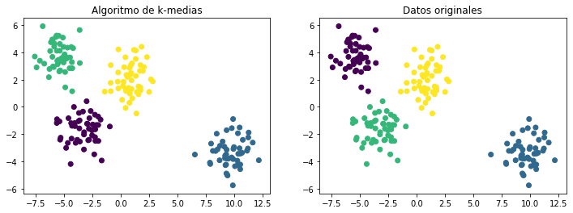

```python
fig, (ax1,ax2) = plt.subplots(1,2,figsize = (12,4))
ax1.scatter(datos[0][:,0],datos[0][:,1],c=modelo.labels_)
ax1.set_title('Algoritmo de k-medias')

ax2.scatter(datos[0][:,0],datos[0][:,1],c= datos[1])
ax2.set_title('Datos originales')
```

Claramente y dado que este es un ejemplo bastante básico, la clasificación es perfecta